# Powell Elevation Projection

Isabel Hinton

2026-05-29

# Description

This is an R Markdown document that displays elevation/storage projections for Lake Powell based on 3 operation strategies: 1. Pre April 2026 Operations: No additional releases from Flaming Gorge Reservoir, 7.48 MAF release from Lake Powell for the 2026 water year. 2. Low Additional Releases from Flaming Gorge: Additional 0.66 MAF release from Flaming Gorge from April 2026 - April 2027, 6 MAF release from Lake Powell for the 2026 water year. 3. High Additional Releases from Flaming Gorge: Additional 1 MAF release from Flaming Gorge from April 2026 - April 2027, 6 MAF release from Lake Powell for the 2026 water year.

These strategies are based on the Bureau of Reclamation’s recent decision to change the target release for Lake Powell from 7.48 MAF to 6 MAF as well as release anywhere from 0.66 MAF to 1 MAF of additional water from Flaming Gorge Reservoir.

Data Sources: Current Storage (df$ResDaily): USBR Hydrodata (https://www.usbr.gov/uc/water/hydrodata/reservoir_data/site_map.html) Inflow Projections (inflow): USBR CRMM 24-Month Study (https://www.usbr.gov/uc/water/hydrodata/crmms/current/crmms_nav.html) Additional Flaming Gorge Release Schedule (fg_release): USBR 2026 Drought Response Operations Plan (https://usbr.gov/ColoradoRiverBasin/documents/dcp/DROA/2026/uc-2026droughtresponseoperationsplan-attachmentsa-h-508-20260423.pdf) Outflow Projections (outflow): USBR CRMM 24-Month Study 10th Percentile Flows - Pre April 2026 Projections are based on April 2026 24-Month Study, the rest are based on the most recent 24-Month Study (https://www.usbr.gov/uc/water/hydrodata/crmms/current/crmms_nav.html) Evaporation Estimations(evap_fun): USBR Hydrodata (https://www.usbr.gov/uc/water/hydrodata/reservoir_data/site_map.html)

Figure 1: Lake Powell Elevation and Storage Projections

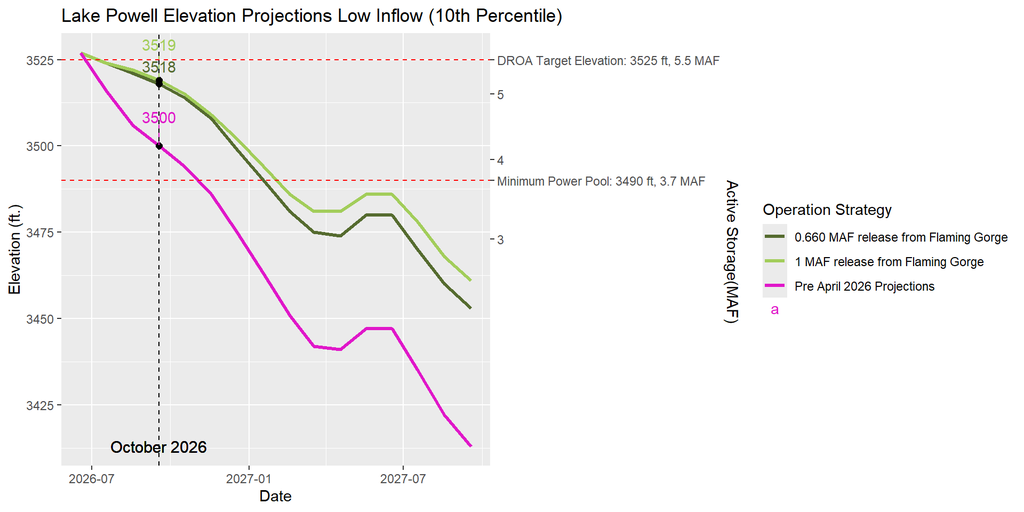